# LCA in R using tidySEM

This is an example of an exploratory LCA using `tidySEM`.

# Loading the Dataset

In this example, we use *data_mix_ordinal*, a simulated data for mixture modelling with ordinal indicators. This dataset is built-in to `tidySEM`. For more information about the dataset, type `?tidySEM::data_mix_ordinal` into the R console after loading the `tidySEM` using library().

We load the dataset and convert the indicators into ordered factors.

```r
library(tidySEM) # loading tidySEM
df <- data_mix_ordinal  # dataset
df[1:4] <- lapply(df, ordered) # indicators as ordered factors
```

# Exploring the Data

An important step to preceding any statistical analysis is data exploration. Here we use `tidySEM::descriptives()` to describe the dataset we are using.

```r
tidySEM::descriptives(df) # descriptives
```

| name | type | n | missing | unique | mean | median | mode | mode_value | sd | v | min | max | range | skew | skew_2se | kurt | kurt_2se |
| --- | --- | --- | --- | --- | --- | --- | --- | --- | --- | --- | --- | --- | --- | --- | --- | --- | --- |
| u1 | ordered, factor | 5000 | 0 | 4 | NA | NA | 2430 | 0 | NA | 0.5972791 | NA | NA | NA | NA | NA | NA | NA |
| u2 | ordered, factor | 5000 | 0 | 4 | NA | NA | 2500 | 0 | NA | 0.5880080 | NA | NA | NA | NA | NA | NA | NA |
| u3 | ordered, factor | 5000 | 0 | 4 | NA | NA | 2426 | 0 | NA | 0.5914019 | NA | NA | NA | NA | NA | NA | NA |
| u4 | ordered, factor | 5000 | 0 | 4 | NA | NA | 2432 | 0 | NA | 0.5901657 | NA | NA | NA | NA | NA | NA | NA |

As we can see, the output includes various descriptives of our dataset. Special attention should be paid to examining the pattern of missingness, as discussed in the *Handling missing data* section of this paper. In our example, we see that there are no missing values, hence we proceed with our analyses.

# Conducting Latent Class Analysis

Before we fit a series of LCA models, we set a random seed using `set.seed()`. The seed number can be any digit. This is an important step as there is some inherent randomness in the LCA computations, and having the same seed number ensures that two separate researcher obtain exactly the same results when fitting LCA models.

Finally, we reach the step of fitting LCA models. To do so, we use `tidySEM::mx_lca()` which takes data and number of classes as inputs. In our example, we want to fit 1 to 4 class solutions and compare their output. Depending on your computer’s computational power, this might take a while.

```r
set.seed(123) # setting seed
res <- mx_lca(data = df, classes = 1:4) # fitting LCA
```

[output not shown]

```
 Solution found!  Final fit=38696.718 (started at 38696.718)  (11 attempt(s): 11 valid, 0 errors)
```

[output not shown]

```
 Solution found!  Final fit=38600.33 (started at 38696.718)  (11 attempt(s): 11 valid, 0 errors)
```

[output not shown]

[output cut: 72 more lines]

[output not shown]

```
 Solution found!  Final fit=38561.615 (started at 38696.718)  (11 attempt(s): 11 valid, 0 errors)
```

[output not shown]

[output cut: 195 more lines]

[output not shown]

```
 Solution found!  Final fit=38549.819 (started at 38696.718)  (11 attempt(s): 11 valid, 0 errors)
```

# Class Enumeration

In class enumeration, we want to compare a sequence of LCA models fitted to the data. To aid the process, we create a model fit table using `tidySEM::table_fit()` with the results object as the input. As the output contains a lot of information on each of the four fitted models, we select a subset of helpful model fit indices and classification diagnostics.

```r
fit_table <- table_fit(res) # model fit table
fit_table[ , c("Name", "LL", "AIC", "BIC", "Entropy", "prob_min", "prob_max", "n_min", "n_max")] # a selection from the model fit table
```

| Name | LL | AIC | BIC | Entropy | prob_min | prob_max | n_min | n_max |
| --- | --- | --- | --- | --- | --- | --- | --- | --- |
| 1 | -19348.36 | 38712.72 | 38764.86 | 1.0000000 | 1.0000000 | 1.0000000 | 1.0000 | 1.0000 |
| 2 | -19300.17 | 38634.33 | 38745.12 | 0.1891980 | 0.6332176 | 0.7706879 | 0.3994 | 0.6006 |
| 3 | -19280.81 | 38613.62 | 38783.06 | 0.5766076 | 0.4745155 | 0.9455837 | 0.1836 | 0.4304 |
| 4 | -19274.91 | 38619.82 | 38847.92 | 0.6203094 | 0.2304808 | 1.0000000 | 0.0442 | 0.5148 |

We discussed several possible strategies to select the final class solution. Here, we apply our own.

To aid our interpretation of the results, we create an elbow plot showing the trends in information criteria across four models.

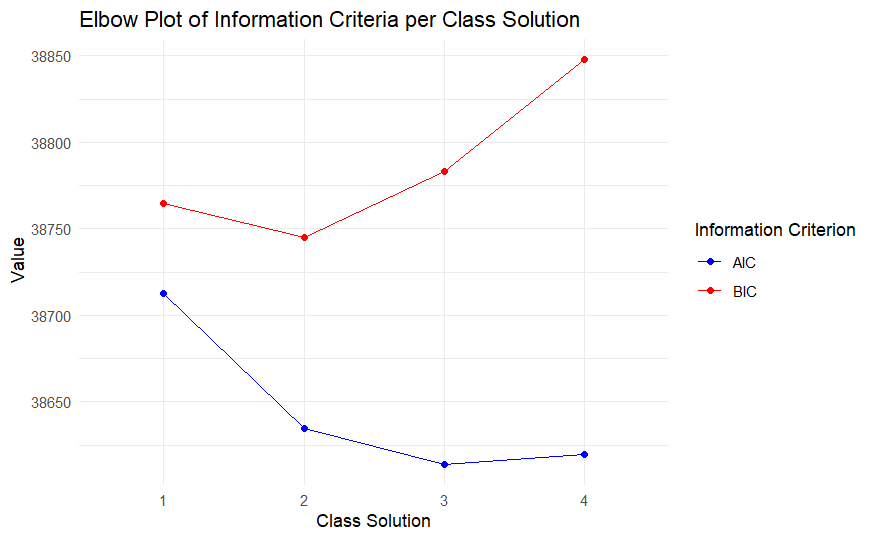

```r
library(tidyverse) # for data-wrangling
library(ggplot2) # for plots

elbow_plot <- fit_table[ , c("Name", "AIC", "BIC")] # extract ICs
elbow_plot %<>% pivot_longer(cols = c("AIC", "BIC"), names_to = "IC", values_to = "Value")

ggplot(elbow_plot, aes(x = Name, y = Value, group = IC))+
  geom_point(aes(color = IC))+
  geom_line(aes(color = IC))+
  labs(title="Elbow Plot of Information Criteria per Class Solution", x = "Class Solution", y = " Value")+
  scale_color_manual(name = "Information Criterion", values = c(AIC = 'blue', BIC = 'red'))+
  theme_minimal()
```

From the elbow plot, we see that AIC has a lower penalty for model complexity. However, we are more interested in the BIC values, which are similar for the one, two and three-class solutions, but the four-class solution fits significantly worse. For this reason, we eliminate the four-class solution from the selection process.

Then we examine the model fit table. As expected, the -2*log likelihood falls successively with each added class. As previously stated, classification diagnostics should not be used for model selection, but they can be used to disqualify certain solutions because they are uninterpretable. We see that prob_min for the four-class solution is low, knowing that this solution also has a high BIC, we disqualify this solution.

Out of the remaining three solutions, we notice that entropy is the highest for the three-class solution, and it has a satisfactory prob_min and n_min. Based on this, we retain the three class solution in model selection. Note that entropy for the one-class solution will always equal to one, as it is 100% true that every case is in that class. Based on the low entropy of the two-class solution, we eliminate this model.

Finally, when comparing the one and three-class solutions, we inspect the information criteria. For BIC, the one-class solution fits better, but the difference is marginal. AIC tells us that the added complexity of having three classes still explains the data better than a one-class solution. Therefore, we select the three-class solution as our final-class solution.

# Interpreting Final Class Solution

If we want to know the probability of each response option’s endorsement for each class, we can use `tidySEM::table_prob`. These are thresholds for ordinal dependent variables in the probability scale.

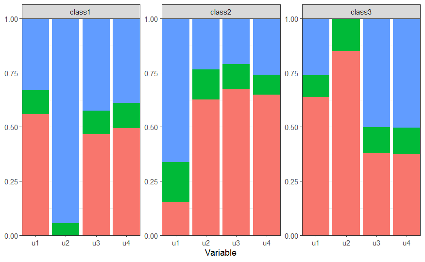

```r
plot_prob(res[[3]]) # plotting the response patterns for the final class solution
```

```r
table_prob(res[[3]]) # tabulating the response patterns for the final class solution
```

| Variable | Category | Probability | group |
| --- | --- | --- | --- |
| u1 | 1 | 5.589172e-01 | class1 |
| u1 | 2 | 1.092231e-01 | class1 |
| u1 | 3 | 3.318597e-01 | class1 |
| u2 | 1 | 0.000000e+00 | class1 |
| u2 | 2 | 5.441587e-02 | class1 |
| u2 | 3 | 9.455841e-01 | class1 |
| u3 | 1 | 4.682808e-01 | class1 |
| u3 | 2 | 1.066286e-01 | class1 |
| u3 | 3 | 4.250906e-01 | class1 |
| u4 | 1 | 4.949024e-01 | class1 |

[output cut: 26 more lines]

We can also interpret the response patterns numerically.

# Extracting Posterior Class Probabilities

Another step is to extract posterior class probabilities. This is done by the use of `TidySEM::class_prob` with the results of the final class solution as the input.

```r
probs <- class_prob(res[[3]]) # extracting the posterior class probabilities of the final class solution
probs$mostlikely.class # posterior class probabilities by most likely class membership
probs$individual # individual posterior class probabilities
```

[output not shown]